# FINAL PROJECT_YMaze_SA Cyt1 flfl

Jacqueline Welday

## Introduction

The Sponataneous Alternation Y Maze is a behavioral assay used to study spatial working memory in mice. The task consists of a 5 minute exploratory phase in which the mouse can freely move about the Y-shaped apparatus. Tracking is done using a digital video camera and ANYMaze Behavioral Tracking Software.

The pattern in which a mouse walks (Starting in Arm 1 and moving to either Arm 2 or 3) is tracked and analyzed using the R script depicted here. A sequence counts as an “Alternation” if 3 unique arms are entered (i.e. Arm1 –> Arm2 –> Arm 3), based on overlapping triplets. If a mouse leaves an arm, returns to the same arm, then leaves to a unique arm, an alternation is also accounted for.

For exmaple, the pattern

**132132313221**

contains 7 Alternations: 132 321 213 132 231 132 3221

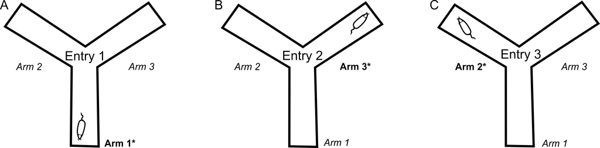

*Image courtesy of Prieur et al (2019)*

We want to see if the mouse’s “Percent Alternation” performace is above/below chance, indicating its choice for/against a novel arm and revealing their spatial working memory. The percent alternation is calculated by the

(total number of alternations)/(number of arms entered) × 100%

for each mouse.

## Import Data

```r
##install.packages('tidyverse')
library (tidyverse)
##install.packages('ggplot2')
library (ggplot2)
#install.packages('dplyr')
library(dplyr)
##install.packages('rio')
library (rio)

## load csv files - the input file name has to be updates each time and the file needs to be in the same project folder as the code
data <- read_csv("102819 YMaze_SA Cyt1 flfl Data_Seq.csv",)
head(data)
```

```
## # A tibble: 6 x 129
##    Test Animal Treatment Time  Date  Distance `Visited zones` X8    X9
##   <dbl>  <dbl> <chr>     <drt> <chr>    <dbl> <chr>           <chr> <chr>
## 1     1   4667 Cre       12:14 10/2…    11.4  Arm 1           Cent… Arm 1
## 2     2   4668 ctrl      12:21 10/2…    14.4  Arm 1           Cent… Arm 3
## 3     3   4669 ctrl      12:28 10/2…    14.3  Arm 1           Cent… Arm 3
## 4     4   5054 cre       12:36 10/2…    14.4  Arm 1           Cent… Arm 3
## 5     5   5055 ctrl      12:43 10/2…    12.8  Arm 1           Cent… Arm 2
## 6     6   4673 cre       12:50 10/2…     9.71 Arm 1           Cent… Arm 3
## # … with 120 more variables: X10 <chr>, X11 <chr>, X12 <chr>, X13 <chr>,
## #   X14 <chr>, X15 <chr>, X16 <chr>, X17 <chr>, X18 <chr>, X19 <chr>,
## #   X20 <chr>, X21 <chr>, X22 <chr>, X23 <chr>, X24 <chr>, X25 <chr>,
## #   X26 <chr>, X27 <chr>, X28 <chr>, X29 <chr>, X30 <chr>, X31 <chr>,
## #   X32 <chr>, X33 <chr>, X34 <chr>, X35 <chr>, X36 <chr>, X37 <chr>,
## #   X38 <chr>, X39 <chr>, X40 <chr>, X41 <chr>, X42 <chr>, X43 <chr>,
## #   X44 <chr>, X45 <chr>, X46 <chr>, X47 <chr>, X48 <chr>, X49 <chr>,
## #   X50 <chr>, X51 <chr>, X52 <chr>, X53 <chr>, X54 <chr>, X55 <chr>,
## #   X56 <chr>, X57 <chr>, X58 <chr>, X59 <chr>, X60 <chr>, X61 <chr>,
## #   X62 <chr>, X63 <chr>, X64 <chr>, X65 <chr>, X66 <chr>, X67 <chr>,
## #   X68 <chr>, X69 <chr>, X70 <chr>, X71 <chr>, X72 <chr>, X73 <chr>,
## #   X74 <chr>, X75 <chr>, X76 <chr>, X77 <chr>, X78 <chr>, X79 <chr>,
## #   X80 <chr>, X81 <chr>, X82 <chr>, X83 <chr>, X84 <chr>, X85 <chr>,
## #   X86 <chr>, X87 <chr>, X88 <chr>, X89 <chr>, X90 <chr>, X91 <chr>,
## #   X92 <chr>, X93 <chr>, X94 <chr>, X95 <chr>, X96 <chr>, X97 <chr>,
## #   X98 <chr>, X99 <chr>, X100 <chr>, X101 <chr>, X102 <chr>, X103 <chr>,
## #   X104 <chr>, X105 <chr>, X106 <chr>, X107 <chr>, X108 <chr>,
## #   X109 <chr>, …
```

## Tidying

```r
n<-nrow(data)

for (i in 1:n){
  animali<- data[i,]
  animali<- animali %>%
    select ('Visited zones', contains("X"))  %>%
    gather(variable, sequence) %>% select(sequence) %>%
    filter(sequence !=('Center'))
  animali<-animali %>%
    mutate (onebefore= lag(sequence)) %>%
    mutate (twobefore=lag(onebefore)) %>%
    mutate(threebefore=lag(twobefore)) %>%
    mutate (alternation1= ifelse(sequence=='Arm 1'& onebefore=='Arm 2' & twobefore=='Arm 3',1,0)) %>%
    mutate (alternation2= ifelse(sequence=='Arm 1'& onebefore=='Arm 3' & twobefore=='Arm 2',1,0)) %>%
    mutate (alternation3= ifelse(sequence=='Arm 2'& onebefore=='Arm 3' & twobefore=='Arm 1',1,0)) %>%
    mutate (alternation4= ifelse(sequence=='Arm 2'& onebefore=='Arm 1' & twobefore=='Arm 3',1,0)) %>%
    mutate (alternation5= ifelse(sequence=='Arm 3'& onebefore=='Arm 1' & twobefore=='Arm 2',1,0)) %>%
    mutate (alternation6= ifelse(sequence=='Arm 3'& onebefore=='Arm 2' & twobefore=='Arm 1',1,0)) %>%
    mutate (alternation7= ifelse(sequence=='Arm 1'& onebefore=='Arm 2' & twobefore=='Arm 2' & threebefore=='Arm 3',1,0)) %>%
    mutate (alternation8= ifelse(sequence=='Arm 1'& onebefore=='Arm 3' & twobefore=='Arm 3' & threebefore=='Arm 2',1,0)) %>%
    mutate (alternation9= ifelse(sequence=='Arm 2'& onebefore=='Arm 1' & twobefore=='Arm 1' & threebefore=='Arm 3',1,0)) %>%
    mutate (alternation10= ifelse(sequence=='Arm 2'& onebefore=='Arm 3' & twobefore=='Arm 3' & threebefore=='Arm 1',1,0)) %>%
    mutate (alternation11= ifelse(sequence=='Arm 3'& onebefore=='Arm 2' & twobefore=='Arm 2' & threebefore=='Arm 1',1,0)) %>%
    mutate (alternation12= ifelse(sequence=='Arm 3'& onebefore=='Arm 1' & twobefore=='Arm 1' & threebefore=='Arm 2',1,0)) %>%
    mutate(A1=as.numeric(alternation1)) %>%
    mutate(A2=as.numeric(alternation2)) %>%
    mutate(A3=as.numeric(alternation3)) %>%
    mutate(A4=as.numeric(alternation4)) %>%
    mutate(A5=as.numeric(alternation5)) %>%
    mutate(A6=as.numeric(alternation6)) %>%
    mutate(A7=as.numeric(alternation7)) %>%
    mutate(A8=as.numeric(alternation8)) %>%
    mutate(A9=as.numeric(alternation9)) %>%
    mutate(A10=as.numeric(alternation10)) %>%
    mutate(A11=as.numeric(alternation11)) %>%
    mutate(A12=as.numeric(alternation12)) %>%
    mutate(alternation=A1+A2+A3+A4+A5+A6+A7+A8+A9+A10+A11+A12) %>%
    select(sequence, onebefore, twobefore, threebefore, alternation)

  animali<-animali[-c(1,2),]

  a<-sum(animali$alternation, na.rm=T)
  #a
  entries<-nrow(animali)
  #entries
  percentage<-a/entries *100
  #as.numeric(percentage)
  ci<-c(data$Animal[i], data$Treatment[i], data$Distance[i], entries, percentage)
  if (i==1) {final<-rbind(ci)} else {final<-rbind(final,ci)}
}

colnames(final)<-c('Animal','Treatment','Distance','Entries','Alternation')
final<-as.data.frame(final)
final<-final %>% arrange(Animal)
final
```

```
##    Animal Treatment Distance Entries      Alternation
## 1    4667       Cre   11.376      26 57.6923076923077
## 2    4668      ctrl   14.446      44 47.7272727272727
## 3    4669      ctrl   14.271      30               60
## 4    4670      ctrl   15.424      42 54.7619047619048
## 5    4671       cre    14.41      45 42.2222222222222
## 6    4673       cre    9.707      26 46.1538461538462
## 7    4674      ctrl   16.393      44 45.4545454545455
## 8    4675       cre    13.43      39 46.1538461538462
## 9    4676      ctrl   12.558      30 36.6666666666667
## 10   4677       cre   18.316      47 53.1914893617021
## 11   4678      ctrl   18.774      42 45.2380952380952
## 12   4679      ctrl   16.943      43 46.5116279069767
## 13   4696       cre    8.588      23 30.4347826086957
## 14   4700       cre   17.731      47 53.1914893617021
## 15   4701       cre   25.909      60               55
## 16   4702      ctrl   19.978      52               50
## 17   5054       cre   14.377      32           59.375
## 18   5055      ctrl   12.845      41 43.9024390243902
```

```r
write.csv(final, file="BIOF339 FINAL PROJECT_Ymaze Cyt1 flfl_tidy.csv")
```

## Statistical Analysis

```r
final2 <- final %>% mutate(Treatment=toupper(Treatment)) %>%
  mutate(Treatment=as.factor(Treatment)) %>%
  mutate(Alternation=as.numeric(as.character(Alternation))) %>%
  mutate(Distance=as.numeric(as.character(Distance))) %>%
  mutate(Animal=as.character(Animal)) %>%
  mutate(Entries=as.numeric(as.character(Entries)))

str(final2)
```

```
## 'data.frame':    18 obs. of  5 variables:
##  $ Animal     : chr  "4667" "4668" "4669" "4670" ...
##  $ Treatment  : Factor w/ 2 levels "CRE","CTRL": 1 2 2 2 1 1 2 1 2 1 ...
##  $ Distance   : num  11.4 14.4 14.3 15.4 14.4 ...
##  $ Entries    : num  26 44 30 42 45 26 44 39 30 47 ...
##  $ Alternation: num  57.7 47.7 60 54.8 42.2 ...
```

```r
YMAze_ttest <- t.test(Alternation~Treatment, data=final2) %>%
  broom::tidy()
print(YMAze_ttest)
```

```
## # A tibble: 1 x 10
##   estimate estimate1 estimate2 statistic p.value parameter conf.low
##      <dbl>     <dbl>     <dbl>     <dbl>   <dbl>     <dbl>    <dbl>
## 1     1.46      49.3      47.8     0.389   0.703      14.7    -6.56
## # … with 3 more variables: conf.high <dbl>, method <chr>,
## #   alternative <chr>
```

```r
Distance_ttest <- t.test(Distance~Treatment, data=final2) %>%
  broom::tidy()
print(Distance_ttest)
```

```
## # A tibble: 1 x 10
##   estimate estimate1 estimate2 statistic p.value parameter conf.low
##      <dbl>     <dbl>     <dbl>     <dbl>   <dbl>     <dbl>    <dbl>
## 1   -0.865      14.9      15.7    -0.443   0.666      11.5    -5.14
## # … with 3 more variables: conf.high <dbl>, method <chr>,
## #   alternative <chr>
```

## Graphs

```r
sem <- function(x) sqrt(var(x, na.rm=T)/sum(!is.na(x)))
plot_data <- final2 %>%
  group_by(Treatment) %>%
  summarise(meanAlt = mean(Alternation), semAlt=sem(Alternation))
plot_data
```

```
## # A tibble: 2 x 3
##   Treatment meanAlt semAlt
##   <fct>       <dbl>  <dbl>
## 1 CRE          49.3   3.03
## 2 CTRL         47.8   2.22
```

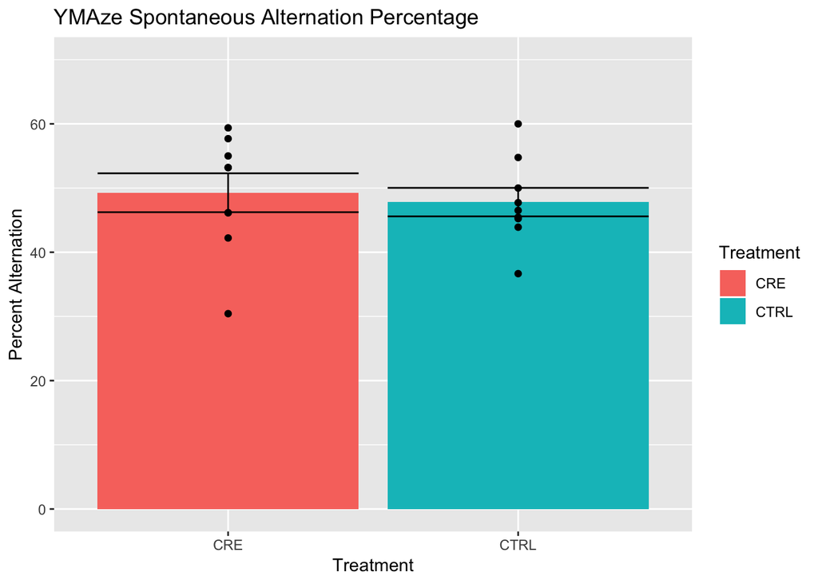

```r
ttest_plot <-  ggplot(data = plot_data,
                      mapping = aes(x = Treatment, y=meanAlt, fill=Treatment)) +
  geom_col()+
  labs(x= "Treatment", y= "Percent Alternation", title= "YMAze Spontaneous Alternation Percentage") +
  geom_errorbar(aes(ymin=meanAlt - semAlt, ymax= meanAlt+semAlt)) +
  ylim(0,70)

ttest_plot <- ttest_plot +
  geom_point(data=final2, mapping = aes(x=Treatment, y=Alternation,
                                        group=Treatment), show.legend = FALSE)
print(ttest_plot)
```

```r
plot_data_dist <- final2 %>%
        group_by(Treatment) %>%
        summarise(meanDist = mean(Distance), semDist=sem(Distance))
plot_data_dist
```

```
## # A tibble: 2 x 3
##   Treatment meanDist semDist
##   <fct>        <dbl>   <dbl>
## 1 CRE           14.9   1.76
## 2 CTRL          15.7   0.846
```

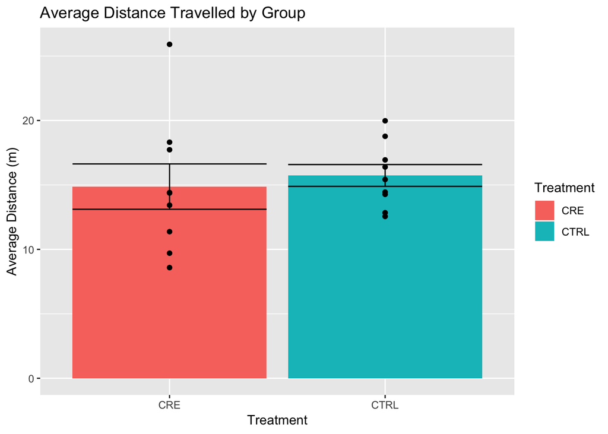

```r
distance_plot <-plot_data_dist %>%
  ggplot(mapping=aes(x=Treatment, y=meanDist, fill=Treatment))+
  geom_col()+
  labs(x="Treatment", y="Average Distance (m)", title="Average Distance Travelled by Group")+
  geom_errorbar(aes(ymin=meanDist - semDist, ymax= meanDist+semDist))

distance_plot <- distance_plot + geom_point(data=final2,
                                            mapping = aes(x=Treatment, y=Distance,
                                                          group=Treatment),
                                            show.legend = FALSE)
print(distance_plot)
```

## Conclusion

Overall, we found no significant difference between our control vs Cre injected floxed mice for both their percent alternation and total distance travelled. Therefore, we can conclude that removing the Cyt1 domain in these mice has no impact on their spatial working memory.

## Citations

Prieur, E. A. and Jadavji, N. M. (2019). Assessing Spatial Working Memory Using the Spontaneous Alternation Y-maze Test in Aged Male Mice. Bio-protocol 9(3): e3162. DOI: 10.21769/BioProtoc.3162.